# Tarea #04

Nadia Bastidas

08 de mayo de 2016

## Sistemas de Recomendacion y Evaluacion de Modelos

### Sistema de Recomendacion

```r
#Se Cargan las librerías y la data

library(arules)
library(arulesViz)

p<-read.csv("periodico.csv")
```

#### Transacciones Bot

```r
#Se realiza la resta de los tiempos de entrada y salida de los usuarios

p$dif<-as.numeric(difftime(p$exit, p$entry))

#Se colocan en la variable "bot" todas aquellas transacciones que duraron menos de 20 segundos

bot<-p[p$dif<=20,]
dim(bot)
```

```
## [1] 2302    6
```

```r
#Se observan 2302 transacciones bot.

#Se eliminan del dataset aquellas transacciones que fueron clasificadas como bots

p<-p[p$dif>20,]
```

#### Se realiza el cambio en la columna articles

Del archivo ejemplo.csv y la informacion dada por el periodico se puede obtener la siguiente clasificacion:

- Son 81 articulos
- Del articulo 1 al 9, tienen contenido “Deportes”
- Del articulo 10 al 18, tienen contenido “Politica”
- Del articulo 19 al 27, tienen contenido “Variedades”
- Del articulo 28 al 36, tienen contenido “Internacional”
- Del articulo 37 al 45, tienen contenido “Nacional”
- Del articulo 46 al 54, tienen contenido “Sucesos”
- Del articulo 55 al 63, tienen contenido “Comunidad”
- Del articulo 64 al 72, tienen contenido “Negocios”
- Del articulo 73 al 81, tienen contenido “Opinion”

```r
#Nombramos la 5ta columna como "items" en lugar de "articles"

names(p)[5]<-"items"

#Dejamos en esta columna únicamente los números de los items separados por coma

p$items<-gsub("item", "", p$items)
p$items<-gsub("(\\{)", "", p$items)
p$items<-gsub("(\\})", "", p$items)
p$items<-gsub(",", " ", p$items)

#Utilizamos la funcion cambio() y clase() para colocar los articulos

cambio<-function(x){
  x <- strsplit(as.character(x), " ")
  x <- as.numeric(unlist(x))
  x <- sapply(x, clase)
  x <- paste(x, collapse=',')
  return(x)
}

clase<-function(x){
  if (x<=9) {
    articulo<-paste("articulo", x, sep = "")
    res <- paste("deportes/", articulo, sep = "")
  }
  else if (x<=18) {
    articulo<-paste("articulo", x-9, sep = "")
    res <- paste("politica/", articulo, sep = "")
  }
  else if (x<=27) {
    articulo<-paste("articulo", x-18, sep = "")
    res <- paste("variedades/", articulo, sep = "")
  }
  else if (x<=36) {
    articulo<-paste("articulo", x-27, sep = "")
    res <- paste("internacional/", articulo, sep = "")
  }
  else if (x<=45) {
    articulo<-paste("articulo", x-36, sep = "")
    res <- paste("nacional/", articulo, sep = "")
  }
  else if (x<=54) {
    articulo<-paste("articulo", x-45, sep = "")
    res <- paste("sucesos/", articulo, sep = "")
  }
  else if (x<=63) {
    articulo<-paste("articulo", x-54, sep = "")
    res <- paste("comunidad/", articulo, sep = "")
  }
  else if (x<=72) {
    articulo<-paste("articulo", x-63, sep = "")
    res <- paste("negocios/", articulo, sep = "")
  }
  else if (x<=81) {
    articulo<-paste("articulo", x-72, sep = "")
    res <- paste("opinion/", articulo, sep = "")
  }
  return(res)
}

p$articles<-sapply(p$items, cambio)
p$items<-NULL
```

#### Tipos de Usuario

Se buscarán las reglas de asociación que cumple este set de datos. Para esto utilizaremos un soporte y confianza determinados.

Se define como soporte “supp(X)” de un itemset como la proporcion de transacciones el data set las cuales contienen dicho itemset

Por otro lado, la confianza de una regla es definida como conf(X => Y) = supp(X U Y)/supp(X).

Se utilizará entonces un valor muy bajo de soporte, pues si este número es muy alto no se generarán suficientes reglas. Esto sucede porque se requeriere entonces que el itemset se repita muchas veces.

Utilizamos el algoritmo apriori para esto

```r
#Creamos la matriz de transacciones

#y<-as.data.frame(p$articles)
#names(y)[1]<-"articles"
#transactions <- as(y,"transactions")

write(p$articles,file="transactions")

transactions <- read.transactions("transactions", format="basket", sep=",")

rules<-apriori(data = transactions, parameter = list(supp=0.00002, conf=0.8))
```

```
## Apriori
##
## Parameter specification:
##  confidence minval smax arem  aval originalSupport support minlen maxlen
##         0.8    0.1    1 none FALSE            TRUE   2e-05      1     10
##  target   ext
##   rules FALSE
##
## Algorithmic control:
##  filter tree heap memopt load sort verbose
##     0.1 TRUE TRUE  FALSE TRUE    2    TRUE
##
## Absolute minimum support count: 2
##
## set item appearances ...[0 item(s)] done [0.00s].
## set transactions ...[81 item(s), 128998 transaction(s)] done [0.05s].
## sorting and recoding items ... [81 item(s)] done [0.01s].
## creating transaction tree ... done [0.15s].
## checking subsets of size 1 2 3 4 5 6 7 done [0.11s].
## writing ... [718 rule(s)] done [0.00s].
## creating S4 object  ... done [0.05s].
```

```r
inspect(rules)
```

```
##     lhs                          rhs                            support confidence       lift
## 1   {nacional/articulo8,
##      negocios/articulo1,
##      negocios/articulo6}      => {nacional/articulo6}      2.325617e-05  1.0000000  31.363482
## 2   {deportes/articulo6,
##      nacional/articulo7,
##      negocios/articulo1}      => {deportes/articulo3}      2.325617e-05  1.0000000   6.454418
## 3   {deportes/articulo4,
##      negocios/articulo1,
##      opinion/articulo3}       => {deportes/articulo1}      2.325617e-05  1.0000000   5.759868
## 4   {comunidad/articulo4,
##      comunidad/articulo8,
##      deportes/articulo2}      => {comunidad/articulo9}     3.100823e-05  1.0000000  31.234383
## 5   {comunidad/articulo4,
##      deportes/articulo4,
##      opinion/articulo9}       => {deportes/articulo2}      2.325617e-05  1.0000000   7.191727
## 6   {comunidad/articulo4,
##      comunidad/articulo9,
##      politica/articulo2}      => {deportes/articulo6}      3.100823e-05  0.8000000   5.188457
## 7   {comunidad/articulo4,
##      deportes/articulo7,
##      politica/articulo8}      => {deportes/articulo5}      3.100823e-05  0.8000000   5.819568
## 8   {comunidad/articulo4,
##      deportes/articulo8,
##      politica/articulo5}      => {deportes/articulo2}      2.325617e-05  1.0000000   7.191727
## 9   {comunidad/articulo1,
##      deportes/articulo1,
##      variedades/articulo3}    => {deportes/articulo3}      2.325617e-05  1.0000000   6.454418
## 10  {comunidad/articulo1,
##      deportes/articulo5,
##      politica/articulo5}      => {deportes/articulo3}      2.325617e-05  1.0000000   6.454418
## 11  {nacional/articulo9,
##      negocios/articulo6,
##      sucesos/articulo4}       => {comunidad/articulo9}     2.325617e-05  1.0000000  31.234383
## 12  {comunidad/articulo9,
##      nacional/articulo9,
##      sucesos/articulo4}       => {negocios/articulo6}      2.325617e-05  1.0000000  39.042978
## 13  {deportes/articulo8,
##      internacional/articulo3,
##      sucesos/articulo4}       => {deportes/articulo4}      2.325617e-05  1.0000000   5.812554
```

[output cut: 2792 more lines]

```
##      deportes/articulo5,
##      deportes/articulo6,
##      nacional/articulo1}      => {deportes/articulo2}      2.325617e-05  1.0000000   7.191727
## 717 {deportes/articulo2,
##      deportes/articulo4,
##      deportes/articulo5,
##      deportes/articulo6,
##      deportes/articulo7,
##      nacional/articulo1}      => {deportes/articulo1}      2.325617e-05  1.0000000   5.759868
## 718 {deportes/articulo1,
##      deportes/articulo2,
##      deportes/articulo4,
##      deportes/articulo6,
##      deportes/articulo7,
##      nacional/articulo1}      => {deportes/articulo5}      2.325617e-05  1.0000000   7.274460
```

Se realizaron pruebas con el soporte y confianza variando entre numeros desde 0.00005 hasta 0.001, en el soporte; y 0.5 a 0.8 en la confianza. Dado que se consiguieron 718 reglas y basada en las definiciones de soporte y confianza se colocaron con valores de 0.00002 y 0.8 respectivamente.

Se crearon un total de 718 reglas.

```r
#Cargamos la librería stringDist

#install.packages("stringdist")
library(stringdist)
consecuente <- inspect(unique(rules@rhs))
```

```
##    items
## 1  {nacional/articulo6}
## 2  {deportes/articulo3}
## 3  {deportes/articulo1}
## 4  {comunidad/articulo9}
## 5  {deportes/articulo2}
## 6  {deportes/articulo6}
## 7  {deportes/articulo5}
## 8  {negocios/articulo6}
## 9  {deportes/articulo4}
## 10 {comunidad/articulo8}
## 11 {deportes/articulo7}
## 12 {deportes/articulo9}
## 13 {opinion/articulo5}
## 14 {internacional/articulo2}
```

[output cut: 32 more lines]

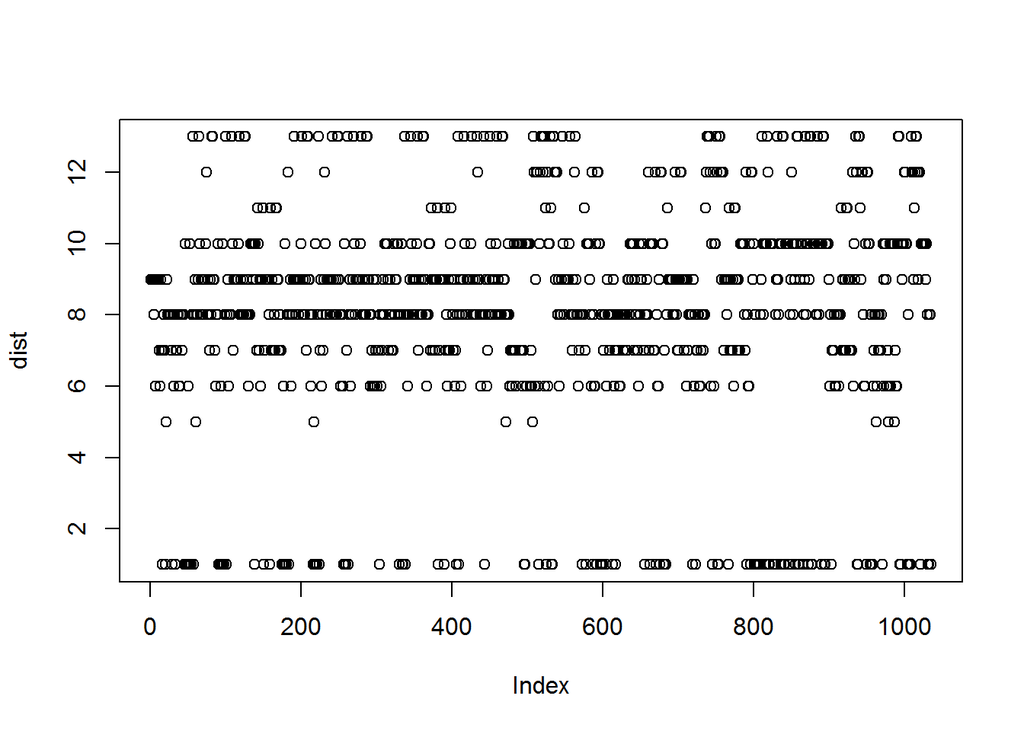

```r
consecuente <- as.character(consecuente$items)

dist <- stringdistmatrix(consecuente)
plot(dist)
```

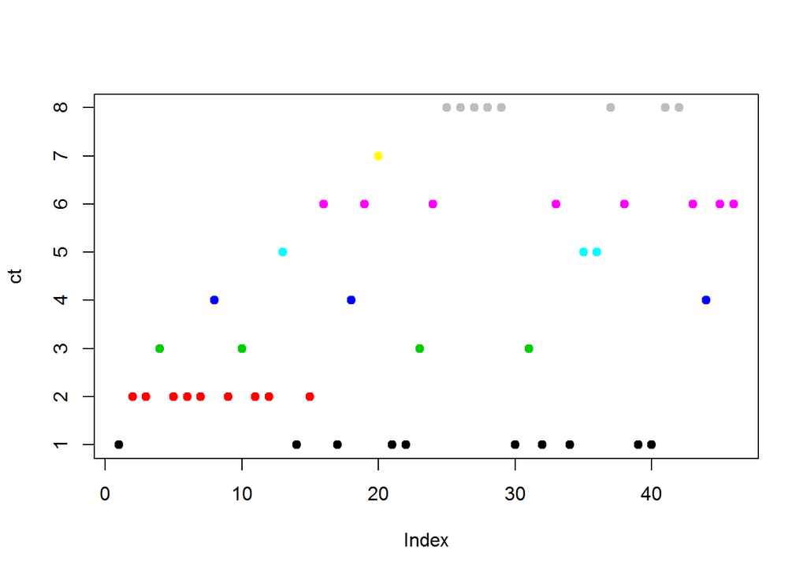

```r
hc <- hclust(dist, method="single")
ct <- cutree(hc, k=8)
plot(ct, col=ct, pch=19)
```

```r
consecuente <- inspect(unique(rules@rhs))
```

```
##    items
## 1  {nacional/articulo6}
## 2  {deportes/articulo3}
## 3  {deportes/articulo1}
## 4  {comunidad/articulo9}
## 5  {deportes/articulo2}
## 6  {deportes/articulo6}
## 7  {deportes/articulo5}
## 8  {negocios/articulo6}
## 9  {deportes/articulo4}
## 10 {comunidad/articulo8}
## 11 {deportes/articulo7}
## 12 {deportes/articulo9}
## 13 {opinion/articulo5}
## 14 {internacional/articulo2}
```

[output cut: 32 more lines]

```r
consecuente$class <- ct

#Proporción de los grupos

table(consecuente$class)
```

```
##
##  1  2  3  4  5  6  7  8
## 10  9  4  3  3  8  1  8
```

Se consiguen entonces 8 grupos de usuarios, los cuales están clasificados por el consecuente de su regla. Esto quiere decir que si las personas buscan un tema, puede ser que les interese otro con una cierta confianza. A aquellos usuarios que con cierta confianza le interesaran algunos articulos se les agrupa entonces.

#### Recomendacion

Para recomendar a algun usuario nuevo se generan las reglas de asociacion creadas en el punto anterior. Una vez que tenemos las reglas, con un soporte y confianza elegidos segun los criterios ya nombrados, se procede a confirmar si existen reglas que tengan como antecedente las transacciones dadas por el usuario nuevo al sistema. Por ejemplo:

```r
new.user <- c("deportes/articulo2")

reglas <- subset(rules, lhs %ain% new.user)
inspect(head(reglas, by="conf"))
```

```
##   lhs                          rhs                         support confidence      lift
## 1 {comunidad/articulo4,
##    comunidad/articulo8,
##    deportes/articulo2}      => {comunidad/articulo9}  3.100823e-05          1 31.234383
## 2 {comunidad/articulo9,
##    deportes/articulo2,
##    sucesos/articulo1}       => {comunidad/articulo8}  2.325617e-05          1 57.614113
## 3 {deportes/articulo2,
##    nacional/articulo3,
##    sucesos/articulo9}       => {deportes/articulo1}   2.325617e-05          1  5.759868
## 4 {deportes/articulo2,
##    internacional/articulo8,
##    sucesos/articulo2}       => {deportes/articulo6}   2.325617e-05          1  6.485571
## 5 {deportes/articulo2,
##    nacional/articulo6,
##    sucesos/articulo5}       => {deportes/articulo8}   2.325617e-05          1  7.162179
## 6 {deportes/articulo2,
##    negocios/articulo9,
##    variedades/articulo7}    => {variedades/articulo2} 2.325617e-05          1 46.789264
```

```r
inspect(head(reglas, by="lift"))
```

```
##   lhs                       rhs                         support confidence     lift
## 1 {deportes/articulo2,
##    deportes/articulo4,
##    variedades/articulo4,
##    variedades/articulo5} => {variedades/articulo1} 2.325617e-05          1 64.14620
## 2 {deportes/articulo2,
##    deportes/articulo8,
##    variedades/articulo6,
##    variedades/articulo8} => {variedades/articulo1} 2.325617e-05          1 64.14620
## 3 {comunidad/articulo9,
##    deportes/articulo2,
##    sucesos/articulo1}    => {comunidad/articulo8}  2.325617e-05          1 57.61411
## 4 {deportes/articulo2,
##    negocios/articulo9,
##    variedades/articulo7} => {variedades/articulo2} 2.325617e-05          1 46.78926
## 5 {comunidad/articulo4,
##    comunidad/articulo8,
##    deportes/articulo2}   => {comunidad/articulo9}  3.100823e-05          1 31.23438
## 6 {deportes/articulo2,
##    deportes/articulo8,
##    variedades/articulo1,
##    variedades/articulo8} => {variedades/articulo6} 2.325617e-05          1 30.83863
```

Dado que muchas reglas tenían la confianza en 1 se eligio recomendar aquella en la cual el indice “lift” fuese mas alto.

#### Conocer las 10 visitas con mayor tiempo de estadía en la página y las 10 visitas con menor tiempo de estadía en la página

```r
#Usuarios con mayor tiempo en la pagina
mayor<-p[order(p$dif, decreasing = TRUE),]
mayor[1:10,]
```

```
##             X         ID               entry                exit   dif
## 93676   93676 trans93676 2016-04-29 14:52:09 2016-04-29 18:16:33 12264
## 7511     7511  trans7511 2016-05-03 06:50:17 2016-05-03 10:14:11 12234
## 80516   80516 trans80516 2016-04-29 17:33:26 2016-04-29 20:49:09 11743
## 122879 122879  trans4579 2016-05-02 02:12:09 2016-05-02 05:25:26 11597
## 130641 130641  trans7341 2016-05-01 00:27:26 2016-05-01 03:39:14 11508
## 66995   66995 trans66995 2016-05-02 21:14:51 2016-05-03 00:26:12 11481
## 111953 111953  trans1653 2016-05-01 16:23:18 2016-05-01 19:33:39 11421
## 23099   23099 trans23099 2016-05-02 06:55:59 2016-05-02 10:06:18 11419
## 55628   55628 trans55628 2016-04-30 03:37:12 2016-04-30 06:46:53 11381
## 48007   48007 trans48007 2016-04-30 01:26:07 2016-04-30 04:35:39 11372
##                                                                                                                 articles
## 93676                                                                              politica/articulo7,negocios/articulo7
## 7511                                                                              politica/articulo5,comunidad/articulo9
## 80516                                                           politica/articulo5,nacional/articulo1,nacional/articulo9
## 122879                                                                             comunidad/articulo3,opinion/articulo6
## 130641                                                      internacional/articulo8,negocios/articulo8,opinion/articulo9
## 66995                                                           deportes/articulo8,deportes/articulo9,negocios/articulo3
## 111953                                                                              nacional/articulo3,sucesos/articulo6
## 23099                                       deportes/articulo3,deportes/articulo5,comunidad/articulo9,negocios/articulo8
## 55628  deportes/articulo4,deportes/articulo5,deportes/articulo8,deportes/articulo9,politica/articulo2,negocios/articulo8
## 48007                                                                              deportes/articulo4,politica/articulo8
```

```r
#Usuarios con menor tiempo en la pagina
menor<-p[order(p$dif, decreasing = FALSE),]
menor[1:10,]
```

```
##           X         ID               entry                exit dif
## 1000   1000  trans1000 2016-05-01 18:57:33 2016-05-01 18:57:54  21
## 1172   1172  trans1172 2016-05-01 07:29:27 2016-05-01 07:29:48  21
## 2144   2144  trans2144 2016-05-01 14:21:16 2016-05-01 14:21:37  21
## 4698   4698  trans4698 2016-05-02 08:22:34 2016-05-02 08:22:55  21
## 5216   5216  trans5216 2016-05-03 00:06:49 2016-05-03 00:07:10  21
## 5765   5765  trans5765 2016-04-30 20:29:02 2016-04-30 20:29:23  21
## 6258   6258  trans6258 2016-05-01 03:57:36 2016-05-01 03:57:57  21
## 11346 11346 trans11346 2016-04-29 19:35:51 2016-04-29 19:36:12  21
## 12413 12413 trans12413 2016-04-30 21:52:42 2016-04-30 21:53:03  21
## 13046 13046 trans13046 2016-04-30 17:03:21 2016-04-30 17:03:42  21
##                                                                          articles
## 1000                    deportes/articulo8,politica/articulo2,comunidad/articulo5
## 1172                                        deportes/articulo1,nacional/articulo2
## 2144                                                           politica/articulo2
## 4698                   deportes/articulo7,politica/articulo5,variedades/articulo6
## 5216  deportes/articulo5,deportes/articulo7,deportes/articulo8,politica/articulo5
## 5765                     deportes/articulo3,politica/articulo9,negocios/articulo9
## 6258                     deportes/articulo4,deportes/articulo7,politica/articulo6
## 11346                                       deportes/articulo7,deportes/articulo9
## 12413                                       deportes/articulo9,negocios/articulo5
## 13046 deportes/articulo1,deportes/articulo4,nacional/articulo5,negocios/articulo6
```

#### Conocer las 10 transacciones con mayor número de apariciones en el dataset.

```r
aparece <- (tail(sort(table(p$articles)), 10))
aparece
```

```
##
## politica/articulo5 deportes/articulo2 deportes/articulo5
##                440                828                850
## deportes/articulo8 deportes/articulo6 deportes/articulo9
##                868                894                904
## deportes/articulo3 deportes/articulo7 deportes/articulo4
##                924               1043               1045
## deportes/articulo1
##               1050
```